# National Flood Hazard Layer Data

Chase Dawson, Michele Claibourn

11/30/2021

## Data Source

- The data represented here come from FEMA’s [National Flood Hazard Layer](https://www.fema.gov/flood-maps/national-flood-hazard-layer), containing current effective flood hazard data, as downloaed through [FEMA Flood Map Service Center.](https://msc.fema.gov/portal/advanceSearch#searchresultsanchor)
- The current data was downloaded in November 2021; the NFHL is being revised continuously.

## Variable Descriptions and Summaries

Variables include:

```
## Rows: 16
## Columns: 7
## $ GEOID     <chr> "51001090200", "51001980200", "51001980100", "51001090400", …
## $ area_2per <dbl> 7.290783, 0.314404, 0.737685, 13.957683, 0.000000, 5.100998,…
## $ area_1per <dbl> 59.342295, 18.215851, 86.170853, 43.355869, 0.455766, 48.300…
## $ area_0    <dbl> 293.06757, 103.26033, 24.92396, 308.89622, 1748.81822, 715.3…
## $ perc_2per <dbl> 2.0255087, 0.2581513, 0.6595840, 3.8113901, 0.0000000, 0.663…
## $ perc_1per <dbl> 16.48634084, 14.95669981, 77.04768101, 11.83908034, 0.026011…
## $ perc_0    <dbl> 81.41936, 84.78515, 22.28518, 84.34953, 99.80946, 93.05313, …
```

- GEOID: geographic identifer for spatial area (tracts, block groups, and blocks)
- area_0: area (in km^2) of block/block group/tract/county that do not intersect with 100-year or 200-year floodplains, or areas with minimal chance of flooding.
- area_1per: area (in km^2) of block/block group/tract/county that intersects with 100-year floodplain, or areas with a 1% annual chance of flooding.
- area_2per: area (in km^2) of block/block group/tract/county that intersects with 100-year floodplain, or areas with a 2% annual chance of flooding. This zone is also used to designate base floodplains of lesser hazards, such as areas protected by levees from 100-year flood, or shallow flooding areas with average depths of less than one foot or drainage areas less than 1 square mile.
- perc_0: percentage of block/block group/tract/county that does not overlap with the 1% or 2% annual flood zone.
- perc_1per: percentage of block/block group/tract/county that overlaps with the 1% annual flood zone.
- perc_2per: percentage of block/block group/tract/county that overlaps with the 2% annual flood zone.

5-number summaries of variables by block groups:

```
##
## Summary Statistics
## ============================================
## Statistic Mean  St. Dev. Min  Median   Max
## --------------------------------------------
## area_2per  2.5    3.2    0.0   1.3    14.5
## area_1per 20.6    23.9   0.0   12.8   86.2
## area_0    165.8  350.4   0.04  60.1  1,748.8
## perc_2per  3.0    3.4    0.0   1.8    13.9
## perc_1per 22.9    22.6   0.0   14.5   87.5
## perc_0    74.9    24.6   0.7   83.2   100.0
## --------------------------------------------
```

## Visual Distributions

### Tracts

Percent of tract in minimal flood, 1% annual floodplain, and 2% annual floodplain zones

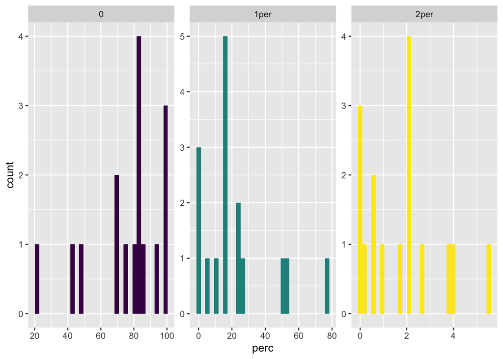

### Block Groups

Percent of block group in minimal flood, 1% annual floodplain, and 2% annual floodplain zones

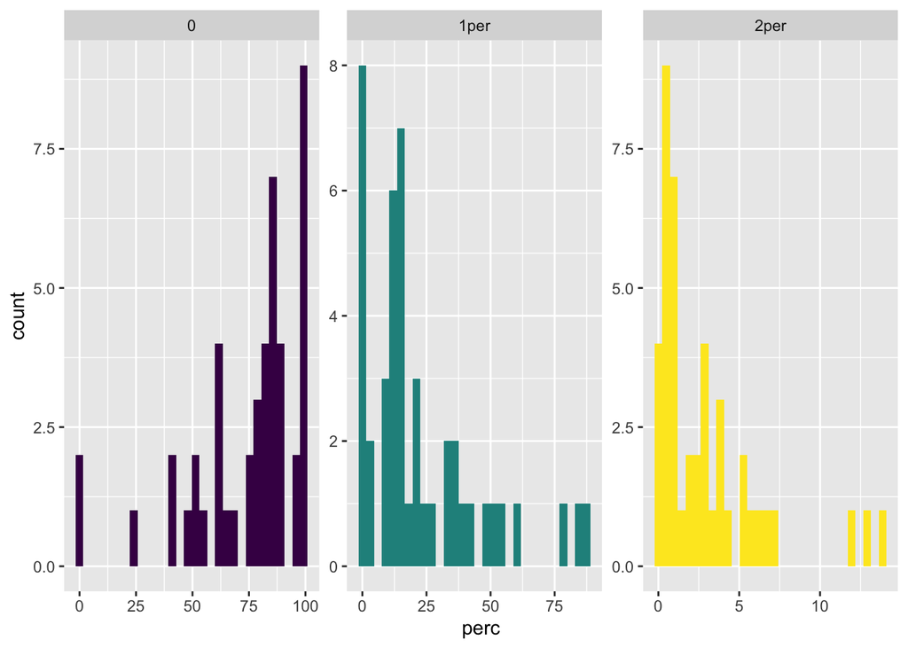

### Blocks

Percent of block in minimal flood, 1% annual floodplain, and 2% annual floodplain zones

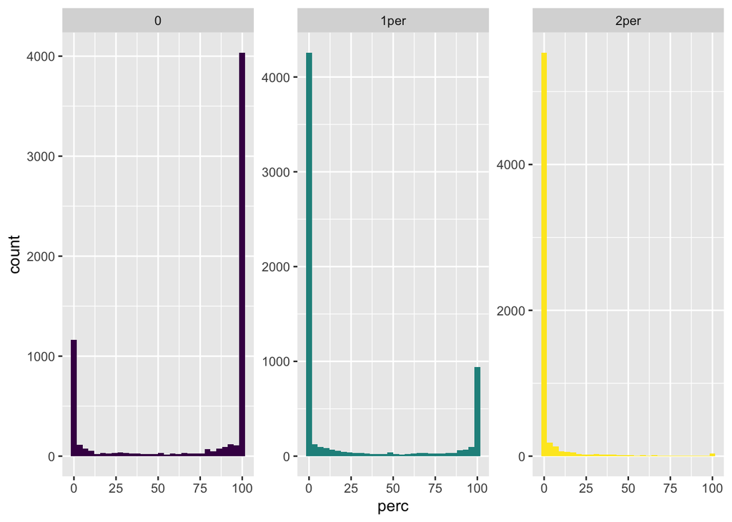

## Maps

### 1% Annual Flood Zone

#### Tracts

[interactive chart not shown]

#### Block Groups

[interactive chart not shown]

#### Blocks

Block level maps are slow to render and may be added later.

### 2% Annual Flood Zone

#### Tracts

[interactive chart not shown]

#### Block Groups

[interactive chart not shown]

#### Blocks

Block level maps are slow to render and may be added later.